# La desigualdad en la participacion politica de las mujeres en las elecciones municipales distritales del 2018

Valeria Lévano Torres, Juan Carlos Pérez Gonzáles, Cristian Serrano, Stephy Riega, André Lama

2023-01-29

## Introducción

La desigualdad en la participación politica de las mujeres ha sido una constante en la escena peruana en todos sus niveles de eleccion. En las organizaciones politicas, las mujeres representaban la mitad de la militancia pero menos del 30% de la dirigencia nacional. Menos del 7% de candidatos a puestos de regidores nacionales han sido mujeres desde la creacion de estos cargos en el 2002. Desde 1995, el primer año en que una mujer formó parte de una candidatura de la fórmula presidencial; menos del 13% de las candidaturas a esta lista han estado compuestas por mujeres (Dirección Nacional de educación y formación cívica ciudadana. 2020).

Con el fin de revertir esto, en las Elecciones Regionales Municipales (ERM) del 2022, se implementó la ley de alternancia en el Peru. Esto aplica para las elecciones presidenciales (toda la fórmula presidencial) , regionales (fórmula al cargo de gobernador y vicegobernado regional) , municipales (lista para los regidores o concejo municipal) , y en los partidos politicos (las listas de los cargos de direccion) (Dirección Nacional de educación y formación cívica ciudadana. 2022).

La ley de paridad y alternancia tuvo impactos en las elecciones internas ERM en terminos de género, siendo la más general que el porcentaje de mujeres candidatas en este tipo de elecciones aumentó en 3.9% en comparación de las elecciones internas del 2018 (43.4%) (Dirección Nacional de educación y formación cívica ciudadana. 2022). Así, parece que la ley de paridad y alternancia se cumplio poniendo a la mujer como segunda al mando en las elecciones internas a nivel regional. El porcentaje de mujeres en las precandidaturas en el 2022 como gobernadora regional fue de 28.3%, mientras que para el puesto de vicegobernador regional fue de 71.7% (Dirección Nacional de educación y formación cívica ciudadana. 2022).

Sin embargo, esta ley no tuvo impacto en las elecciones municipales para las fórmulas de alcaldia en las elecciones internas ERM 2022, a pesar de que las mujeres candidatas nunca han representado más del 8% del total de las candidaturas. Tanto para los puestos de alcalde provincial como de alcalde distrital, el porcentaje de las precandidaturas de mujeres se mantuvo menor al 15% (10.6% y 11.2%, respectivamente) (Dirección Nacional de educación y formación cívica ciudadana. 2022).

Debido a esto, buscamos exponer con el siguiente trabajo la desigualdad que aún persiste en la participacion de la mujer en las últimas elecciones ERM municipales a nivel distrital. Esto, con el fin de entender por qué se deberian realizar este trabajo pendiente de aplicar la ley a este nivel y adoptar las medidas para revertir esta desigualdad en la participacion politica de las mujeres.

Consideramos importante un trabajo descriptivo puesto que podria ser fundamental para el estudio posterior En aquellas circunstancias en las que el conocimiento sobre un topico es menor del que se quisiera, la descripcion es necesaria (Gerring, 2012). Es decir, si es que queremos determinar el posible efecto que pueda tener la ley de paridad y alternancia en las elecciones de este tipo, debemos saber sobre aquella de lo que se va buscar hallar su causa segun las caracteristicas que este tenga. Aun así, el ejercicio de descripcion es relevante y propio de estudio por como podemos ver este fenómeno de desigualdad (Gerring, 2012).

Por un lado, como definimos la desigualdad en la participacion importa pues, como otro diversos fenomenos estudiados, podemos hablar de la carencia absoluta y relativa. Es decir, podemos optar por la definición de desigualdad comparando si es que, a ciertos niveles, no se alcanzó el 50% de mujeres elegidas en puesto; o acercarnos a esta definicion en comparación no del 50%, sino del porcentaje promedio que se haya encontrado a estos niveles (que, por ejemplo, pueda ser 30%).

Antes de esta ley, no existía una determinada norma que obligara la postulacion participación equitativa de las mujeres en los cargos ,ejecutivos como concejales, o en las preferencia en las listas, de regidores o consejo municipal . Es decir, puede que este último porcentaje que planteamos sea mínimo. Aun así, consideramos que es importante de evaluar pues nos puede dar un indicio de que unidades presentan avances mínimos hacia la igualdad de la participación politicas de las mujeres, aun sin una ley que los obligara.

## Metodología

El procesamiento de los datos se realizará con el paquete *dlpyr* de *tidyverse* y los gráficos con el paquete *ggplot2*, otras extensiones de este paquete como *ggmosaic*, *magrittr* y *gganimate* y para graficar los mapas del Perú usamos el paquete *mapsPERU*.

## Resultados

### Los candidatos

```r
#Activamos las librerías
library(readxl)
library(ggplot2)
library(ggpol)
library(rio)
library(dplyr)
library(tidyverse)
library(magrittr)
library(mapsPERU)
library(sf)
library(ggmosaic)
```

```r
#Importación de datos----
#primero fijamos el directorio donde se ubican los archivos
setwd(paste0(getwd(), "/BD/MUNICIPAL DISTRITAL 2018"))
#Importamos en dataframe cada uno de los archivos
candidatos <- read_xlsx("ERM2018_Candidatos_Distrital.xlsx")
padron <- read_xlsx("ERM2018_Padron_Distrital.xlsx")
resultados <- read_xlsx("ERM2018_Resultados_Distrital.xlsx")
autoridades <- read_xlsx("ERM2018_Autoridades_Distrital.xlsx")
```

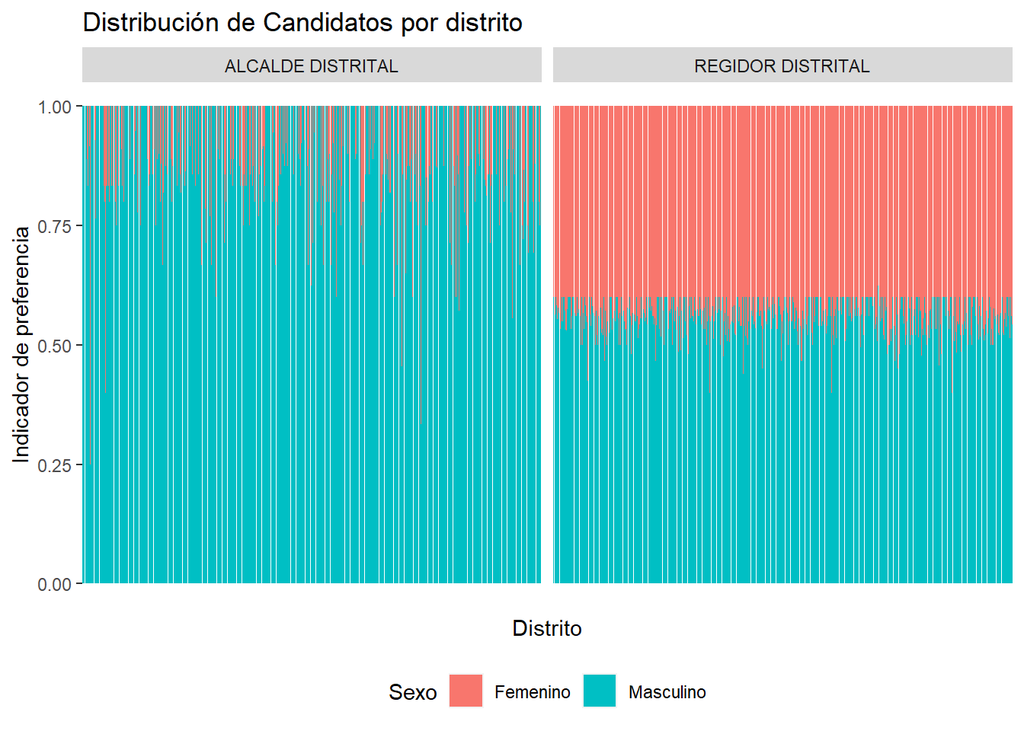

```r
### Grafico de indicador de preferencia por sexo y distrito ----
candidatos %>%
  group_by(Sexo, Cargo, Distrito) %>%
  summarize(count = n()) %>%
  # Crea el gráfico mediante ggplot
  ggplot(aes(x = Distrito, y = count, fill = Sexo)) +
  # Agrega barra con tamaño proporcional a la cantidad de candidatos
  geom_bar(stat = "identity", position = "fill") +
  facet_wrap(~ Cargo ) + #divide el gráfico por cargo
  #Para colocar la leyenda en la parte inferior del gráfico y para no colocar los nombres de Distro en eje x
  theme(legend.position = "bottom", axis.text.x = element_blank(), axis.ticks.x = element_blank()) +
  # Coloca etiquetas y título. En este gráfico no se considera los nombres del eje x debido a su extensión
  ylab("Indicador de preferencia") +
  ggtitle("Distribución de Candidatos por distrito")
```

```r
### Grafico de indicador de preferencia por sexo y distrito ----
unique(candidatos$Region)
```

```
##  [1] "AMAZONAS"      "ANCASH"        "APURIMAC"      "AREQUIPA"
##  [5] "AYACUCHO"      "CAJAMARCA"     "CUSCO"         "HUANCAVELICA"
##  [9] "HUANUCO"       "ICA"           "JUNIN"         "LA LIBERTAD"
## [13] "LAMBAYEQUE"    "LIMA"          "LORETO"        "MADRE DE DIOS"
## [17] "MOQUEGUA"      "PASCO"         "PIURA"         "PUNO"
## [21] "SAN MARTIN"    "TACNA"         "TUMBES"        "CALLAO"
## [25] "UCAYALI"
```

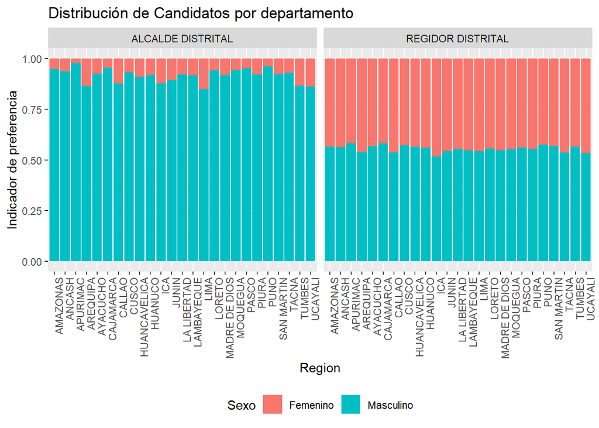

```r
candidatos %>%
  group_by(Region, Sexo, Cargo, Distrito) %>%
  summarize(count = n()) %>%
  ggplot(aes(x = Region, y = count, fill = Sexo)) +
  # Agrega barra con tamaño proporcional a la cantidad de candidatos
  geom_bar(stat = "identity", position = "fill") +
  facet_wrap(~ Cargo ) + #divide el gráfico por cargo
  # Para colocar la leyenda en la parte inferior del gráfico
  theme(legend.position = "bottom") +
  # Coloca etiquetas y título
  xlab("Region") +
  ylab("Indicador de preferencia") +
  ggtitle("Distribución de Candidatos por departamento")+
  # Ayuda a convertir los nombres horizontales en verticales, para que no aparezcan superpuestos
  theme(axis.text.x = element_text(angle = 90, hjust = 1))
```

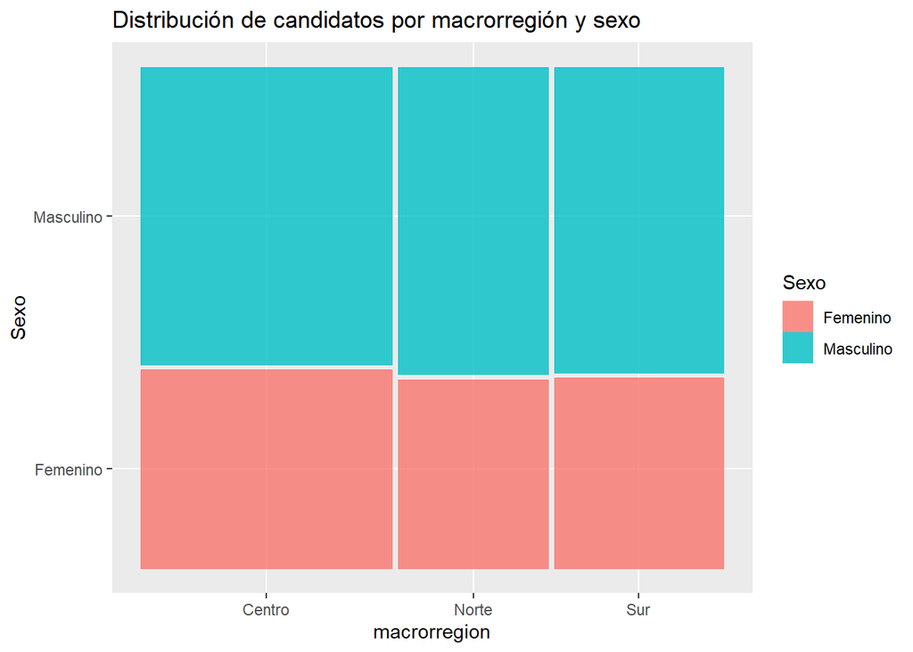

```r
#Distribución de candidatos por Macrorregión (Norte, Centro y Sur)
#Llenamos los valores vacíos de las variables Joven y Nativo
#Luego, agrupamos los departamentos en macrorregiones

candidatos_2 <- candidatos |>
  mutate(Joven = ifelse(is.na(Joven), "No Joven", Joven)) |>
  mutate(Nativo = ifelse(is.na(Nativo), "No Nativo", Nativo)) |>
  mutate(macrorregion = if_else(Region %in% c("AMAZONAS" , "CAJAMARCA","LA LIBERTAD", "LAMBAYEQUE", "LORETO", "PIURA", "SAN MARTIN", "TUMBES"), "Norte",
                                if_else(Region %in% c("LIMA","ANCASH", "CALLAO", "HUANCAVELICA", "HUANUCO", "JUNIN","MADRE DE DIOS", "PASCO", "UCAYALI"), "Centro",
                                        if_else(Region %in% c("AREQUIPA","APURIMAC", "AYACUCHO", "CUSCO","ICA","MOQUEGUA", "PUNO", "TACNA"), "Sur", "NA"))))

candidatos_2 |>
  group_by(macrorregion, Sexo) |>
  ggplot()+
  geom_mosaic(aes(x = product(macrorregion), fill=Sexo)) +
  ggtitle("Distribución de candidatos por macrorregión y sexo")
```

Los gráficos presentados muestran la desigualdad en la distribución de candidaturas según el cargo, utilizando un indicador de preferencia basado en la cantidad de candidatos. Ambos gráficos, tanto el de distrito como el de departamento, ilustran la brecha entre hombres y mujeres en la participación política. En el gráfico de distrito, se observa que el grupo de alcaldes distritales tiene una mayor cantidad de candidatos masculinos en comparación con las candidatas. Por otro lado, en el grupo de regidores distritales, se ve una mayor participación femenina. Sin embargo, en ambos grupos, los candidatos masculinos tienen una mayor representación en términos del indicador de preferencia. En el gráfico de departamento se aprecia una similar distribución de candidaturas, mostrando la brecha de género en la política.

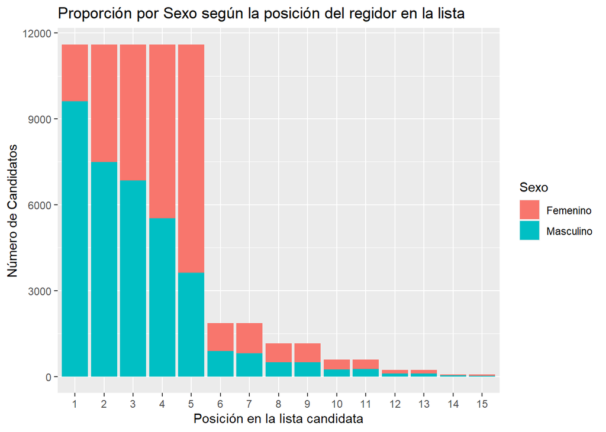

```r
#Prioridad del candidato a regidor en la lista postulante
#Primeros agrupamos los candidatos de acuerdo a su posición en la lista
#calculamos la cantidad por cada posición y sexo

indice <-candidatos |>
  mutate(grupo = cut(`N°`, breaks = seq(from = min(`N°`), to = max(`N°`), by = 1))) |>
  group_by(grupo, Sexo) |>
  summarise(nro_candidatos=n())

#realizamos un grafico de barras
indice <-as.data.frame(indice)
indice|>
  filter(!is.na(grupo)) |>
  ggplot()+
  aes(x=grupo, fill=Sexo) +
  aes(y=nro_candidatos)+
  geom_bar(stat = "identity", position = "stack")+
  scale_x_discrete(labels = c("1", "2", "3","4", "5","6","7","8","9","10","11","12","13","14","15"))+
  labs(title = "Proporción por Sexo según la posición del regidor en la lista") +
  xlab("Posición en la lista candidata") +
  ylab("Número de Candidatos")
```

Por otro lado, resulta importante también a analizar la lista de regidores por la posición que ocupa un sexo u otro. A partir de este grafico, se denota que predomina el género masculino en los tres primeros números de una lista para regidores. En cambio, la participación femenina recién es mayor a partir del número cuatro o cinco. De esta manera, se puede concluir que de ganar cierto alcalde, los regidores que serán elegidos de su lista serán hombres.

```r
#Mapa de calor
#construnimos un mapa
#primero, agrupamos los candidatos por departamento, cargo, sexo
#calculamos el porcenatje de participacion por sexo
#luego, cambiamos los valores de la variable region para poder realizar el join
#https://github.com/musajajorge/mapsPERU

candidatos_map <- candidatos_2 |>
  group_by(Region,Cargo, Sexo,) |>
  summarize(count = n()) |>
  mutate(percent = count / sum(count) * 100) |>
  mutate(Region=recode(Region,
                       "AMAZONAS"="Amazonas",
                         "ANCASH"="Áncash",
                         "APURIMAC"="Apurímac",
                         "AREQUIPA"="Arequipa",
                         "AYACUCHO"="Ayacucho",
                         "CAJAMARCA"="Cajamarca",
                         "CALLAO"="Callao",
                         "CUSCO"="Cusco",
                         "HUANCAVELICA"="Huancavelica",
                         "HUANUCO"="Huánuco",
                         "ICA"="Ica",
                         "JUNIN"="Junín",
                         "LA LIBERTAD"="La Libertad",
                         "LAMBAYEQUE"="Lambayeque",
                         "LIMA"="Lima",
                         "LORETO"="Loreto",
                         "MADRE DE DIOS"="Madre de Dios",
                         "MOQUEGUA"="Moquegua",
                         "PASCO"="Pasco",
                         "PIURA"="Piura",
                         "PUNO"="Puno",
                         "SAN MARTIN"="San Martín",
                         "TACNA"="Tacna",
                         "TUMBES"="Tumbes",
                         "UCAYALI"="Ucayali"))

#importamos el shape file del mapa de la libreria mapsPERU
df_mapa <- map_DEP

# realizamos la union de los dos df
df_mapa<-left_join(df_mapa, candidatos_map, by=c("DEPARTAMENTO"="Region"))
```

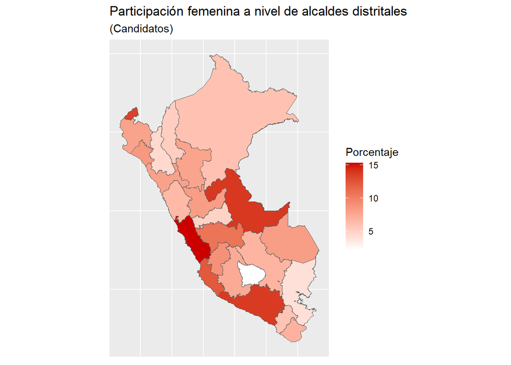

```r
#graficamos el mapa incluyendo el porcentaje de participacion femenina
#para ello filtramos el sexo femenino y cargo igual a alcalde distrital,
#puesto que se desea saber el comportamiento de los candidatos a alcalde
df_mapa |>
filter(Sexo=="Femenino", Cargo=="ALCALDE DISTRITAL") |>
ggplot() +
  aes(geometry=geometry)+
  geom_sf(aes(fill=percent)) +
  scale_fill_gradient (low="white", high="red3", name = "Porcentaje")+
  labs(title = "Participación femenina a nivel de alcaldes distritales",
       subtitle="(Candidatos)") +
  theme(axis.line = element_blank(),
        axis.text.x = element_blank(),
        axis.text.y = element_blank(),
        axis.ticks = element_blank(),
        axis.title.x = element_blank(),
        axis.title.y = element_blank())
```

A partir de este grafico, se denota que, a nivel de alcaldes distritales, los departamos en los que ha habido mayor participación femenina son los siguientes: Lima, Tumbes, Arequipa y Ucayali. En contraposición a ello, se denota que los departamentos en donde ha habido menos participación son Apurímac, Puno y Cajamarca.

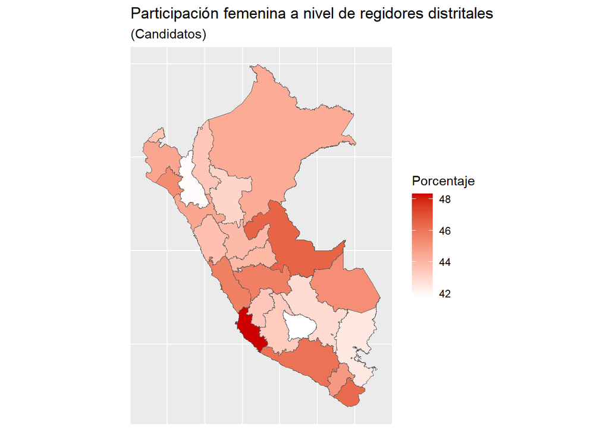

```r
# de igual, se realiza el mapa para los candidatos a regidro
df_mapa |>
  filter(Sexo=="Femenino", Cargo=="REGIDOR DISTRITAL") |>
  ggplot() +
  aes(geometry=geometry)+
  geom_sf(aes(fill=percent)) +
  scale_fill_gradient (low="white", high="red3", name = "Porcentaje")+
  labs(title = "Participación femenina a nivel de regidores distritales",
       subtitle="(Candidatos)") +
  theme(axis.line = element_blank(),
        axis.text.x = element_blank(),
        axis.text.y = element_blank(),
        axis.ticks = element_blank(),
        axis.title.x = element_blank(),
        axis.title.y = element_blank())
```

```r
#similar al df de candidatos, se llena los valores vacios
# se agrupa los departamentos pr macrorregion

autoridades_2 <- autoridades |>
  mutate(Joven = ifelse(is.na(Joven), "No Joven", Joven)) |>
  mutate(Nativo = ifelse(is.na(Nativo), "No Nativo", Nativo)) |>
  mutate(macrorregion = if_else(Región %in% c("AMAZONAS" , "CAJAMARCA","LA LIBERTAD", "LAMBAYEQUE", "LORETO", "PIURA", "SAN MARTIN", "TUMBES"), "Norte",
                                if_else(Región %in% c("LIMA","ANCASH", "CALLAO", "HUANCAVELICA", "HUANUCO", "JUNIN","MADRE DE DIOS", "PASCO", "UCAYALI"), "Centro",
                                        if_else(Región %in% c("AREQUIPA","APURIMAC", "AYACUCHO", "CUSCO","ICA","MOQUEGUA", "PUNO", "TACNA"), "Sur", "NA"))))

# se calcula el porcentaje de participacion por sexo
#y recodifica los valores de la variable region
autoridades_map <- autoridades_2 |>
  group_by(Región, `Cargo electo`, Sexo) |>
  summarize(count = n()) |>
  mutate(percent = count / sum(count) * 100) |>
  mutate(Región=recode(Región,
                       "AMAZONAS"="Amazonas",
                       "ANCASH"="Áncash",
                       "APURIMAC"="Apurímac",
                       "AREQUIPA"="Arequipa",
                       "AYACUCHO"="Ayacucho",
                       "CAJAMARCA"="Cajamarca",
                       "CALLAO"="Callao",
                       "CUSCO"="Cusco",
                       "HUANCAVELICA"="Huancavelica",
                       "HUANUCO"="Huánuco",
                       "ICA"="Ica",
                       "JUNIN"="Junín",
                       "LA LIBERTAD"="La Libertad",
                       "LAMBAYEQUE"="Lambayeque",
                       "LIMA"="Lima",
                       "LORETO"="Loreto",
                       "MADRE DE DIOS"="Madre de Dios",
                       "MOQUEGUA"="Moquegua",
                       "PASCO"="Pasco",
                       "PIURA"="Piura",
                       "PUNO"="Puno",
                       "SAN MARTIN"="San Martín",
                       "TACNA"="Tacna",
                       "TUMBES"="Tumbes",
                       "UCAYALI"="Ucayali"))
```

Respecto a este grafico, cabe resaltar que, en contraposición al anterior, la participación femenina alcanza una mayor proporción llegando casi al 50% a diferencia del 15% a nivel de alcaldes distritales. Asimismo, se denota que los departamos con mayor proporción femenina a nivel de regidores distritales son los siguientes: Ica, Ucayali, Arequipa y Tacna. Sin embargo, se denota que los departamentos en donde ha habido menos participación son Apurímac, Puno y Cajamarca.

En conclusión, se observa que existe una tendencia que la menor participación femenina se encuentre en los departamentos de Apurímac, Puno y Cajamarca, pues en ambos gráficos se han resaltado por ello.

### Las autoridades electas

```r
#Primero comprobamos que clase es la variable joven para poder completar la categoria faltante, como para la variable nativo.
class(autoridades$Joven)
```

```
## [1] "character"
```

```r
autoridades <- autoridades |>
  dplyr::mutate(Joven = ifelse(is.na(Joven), "No Joven", Joven)) |>
  dplyr::mutate(Nativo = ifelse(is.na(Nativo), "No Nativo", Nativo))

autoridades <- as.data.frame(autoridades)
```

```r
### Gráfico de parlamento de las ganadores a regidores municipales distritales por juventud y sexo ----

#Creamos un cuadro resumen para ver la cantidad de REGIDORES DISTRITALES electos, filtrando solo este grupo usando filter().
#Luego, agrupamos estas observaciones por si son jovenes o no y su sexo con la funcion group_by()
#Por ultimo, resumimos estos datos contando cuantas observaciones existen, lo reducimos a centenas y redondeamos.

aut_sum <- autoridades |>
  filter(autoridades$`Cargo electo`== "REGIDOR DISTRITAL") |>
  dplyr::group_by(Joven, Sexo) |>
  dplyr::summarise(regidores=round(n()/100))

#para elaborar el cuadro, debemos agregar la columna de colors con el color correspondiente que queramos usando mutate.
#Sin embargo, este esta determinado por la combinacion entre Joven y Sexo que se haga, por ello usamos case_when.
aut_sum <-aut_sum |>

  mutate(colors = case_when(Joven == 'Joven' & Sexo == 'Femenino' ~ 'lightpink',
                            Joven == 'Joven' & Sexo == 'Masculino' ~ 'lightblue',
                            Joven == 'No Joven' & Sexo == 'Femenino' ~ 'red',
                            Joven == 'No Joven' & Sexo == 'Masculino' ~ 'blue'

  )) |>
  mutate(Sexo_Joven = case_when(Joven == 'Joven' & Sexo == 'Femenino' ~ 'Joven Femenina',
                                Joven == 'Joven' & Sexo == 'Masculino' ~ 'Joven Masculino',
                                Joven == 'No Joven' & Sexo == 'Femenino' ~ 'No joven femenina',
                                Joven == 'No Joven' & Sexo == 'Masculino' ~ 'No joven masculino'))
```

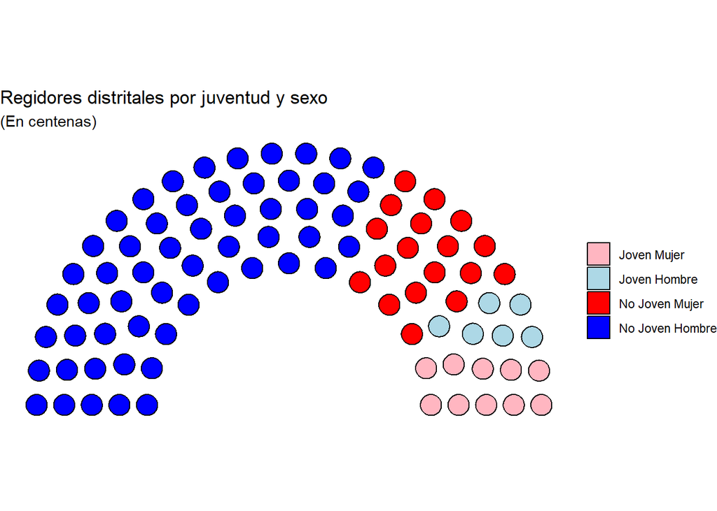

```r
#Por ultimo, usamos una extension de ggplot, geom_parluament, para representar a los regidores distritales por juventud y sexo.
aut_sum |>
  ggplot() +
  geom_parliament(aes(seats = regidores, fill = Joven), color = "black") +
  scale_fill_manual(values = aut_sum$colors, labels = aut_sum$Joven) +
  coord_fixed() +
  theme_void()+
  labs(title = "Regidores distritales por juventud y sexo",
       subtitle="(En centenas)")+
  scale_fill_manual(name = "",
                    values = aut_sum$colors,
                    labels = c("Joven Mujer", "Joven Hombre", "No Joven Mujer", "No Joven Hombre"))
```

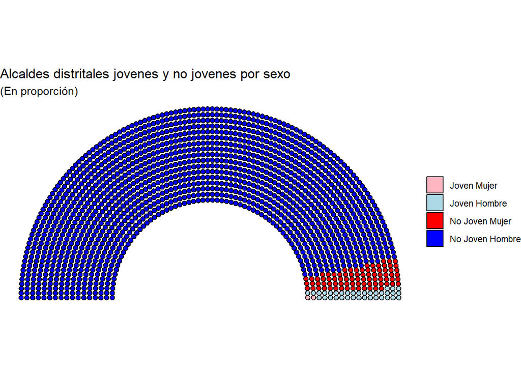

```r
### Gráfico de parlamento de las ganadores a alcaldia municipal distrital jovenes y no jovenes por sexo ----


aut_sum2 <- autoridades |>
  filter(autoridades$`Cargo electo`== "ALCALDE DISTRITAL") |>
  dplyr::group_by(Joven, Sexo) |>
  dplyr::summarise(alcaldes=round(n()))

aut_sum2 <-aut_sum2 |>
  mutate(colors = case_when(Joven == 'Joven' & Sexo == 'Femenino' ~ 'lightpink',
                            Joven == 'Joven' & Sexo == 'Masculino' ~ 'lightblue',
                            Joven == 'No Joven' & Sexo == 'Femenino' ~ 'red',
                            Joven == 'No Joven' & Sexo == 'Masculino' ~ 'blue'
  )) |>
mutate(Sexo_Joven = case_when(Joven == 'Joven' & Sexo == 'Femenino' ~ 'Joven Femenina',
                              Joven == 'Joven' & Sexo == 'Masculino' ~ 'Joven Masculino',
                              Joven == 'No Joven' & Sexo == 'Femenino' ~ 'No joven femenina',
                              Joven == 'No Joven' & Sexo == 'Masculino' ~ 'No joven masculino'))

aut_sum2 |>
ggplot() +
  geom_parliament(aes(seats = alcaldes, fill = Joven), color = "black") +
  scale_fill_manual(name = "",
                    values = aut_sum2$colors,
                    labels = c("Joven Mujer", "Joven Hombre", "No Joven Mujer", "No Joven Hombre")) +
  coord_fixed() +
  theme_void()+
  labs(title = "Alcaldes distritales jovenes y no jovenes por sexo",
       subtitle="(En proporción)")
```

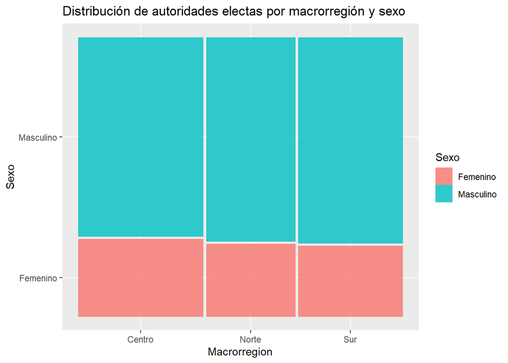

```r
#Distribución de autoridades elegidas por macrorregion
autoridades_2 <- autoridades |>
  mutate(Joven = ifelse(is.na(Joven), "No Joven", Joven)) |>
  mutate(Nativo = ifelse(is.na(Nativo), "No Nativo", Nativo)) |>
  mutate(Macrorregion = if_else(Región %in% c("AMAZONAS" , "CAJAMARCA","LA LIBERTAD", "LAMBAYEQUE", "LORETO", "PIURA", "SAN MARTIN", "TUMBES"), "Norte",
                                if_else(Región %in% c("LIMA","ANCASH", "CALLAO", "HUANCAVELICA", "HUANUCO", "JUNIN","MADRE DE DIOS", "PASCO", "UCAYALI"), "Centro",
                                        if_else(Región %in% c("AREQUIPA","APURIMAC", "AYACUCHO", "CUSCO","ICA","MOQUEGUA", "PUNO", "TACNA"), "Sur", "NA"))))

autoridades_2 |>
  group_by(Macrorregion, Sexo) |>
  ggplot()+
  geom_mosaic(aes(x = product(Macrorregion), fill=Sexo)) +
  ggtitle("Distribución de autoridades electas por macrorregión y sexo")
```

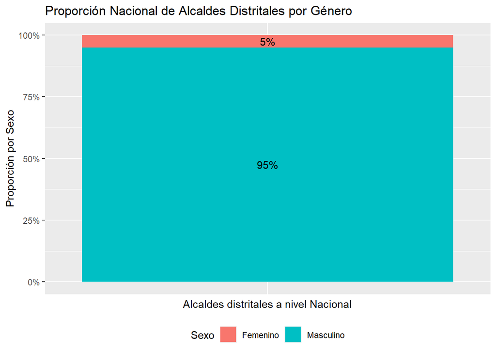

```r
#Gráfico a nivel nacional de la proporción de alcades distritales por sexo:

autoridades %>%
  filter(`Cargo electo` == "ALCALDE DISTRITAL") %>%
  group_by(Sexo) %>%
  summarize(count = n()) %>%
  mutate(percent = count/sum(count)) %>%
  ggplot(aes(x = "", y = percent, fill = Sexo)) +
  geom_bar(width = 1, stat = "identity", position = "fill") +
  geom_text(aes(label = scales::percent(percent)), position = position_stack(vjust = 0.5))+
  scale_y_continuous(labels = scales::percent) +
  ggtitle("Proporción Nacional de Alcaldes Distritales por Género") +
  xlab("Alcaldes distritales a nivel Nacional") +
  ylab("Proporción por Sexo") +
  theme(legend.position = "bottom", axis.text.x = element_blank(), axis.ticks.x = element_blank())
```

```r
#ggsave("grafico1.png", plot = last_plot(), width = 6, height = 4, units = "in")
```

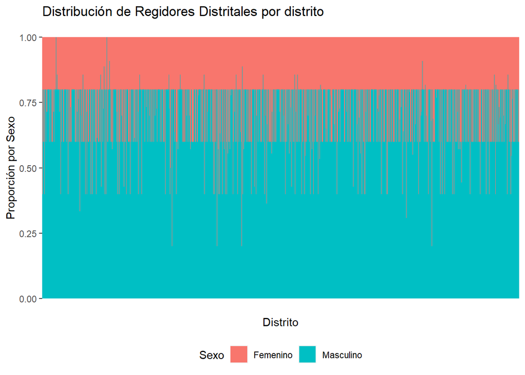

```r
### Grafico de regidores distritales por sexo y distrito ----

autoridades %>%
  filter(`Cargo electo` == "REGIDOR DISTRITAL") %>%
  group_by(Sexo, Distrito) %>%
  summarize(count = n()) %>%
  ggplot(aes(x = Distrito, y = count, fill = Sexo)) +
  geom_bar(stat = "identity", position = "fill") +
  theme(legend.position = "bottom", axis.text.x = element_blank(), axis.ticks.x = element_blank()) +
  ylab("Proporción por Sexo") +
  ggtitle("Distribución de Regidores Distritales por distrito")
```

```r
#ggsave("grafico2.png", plot = last_plot(), width = 6, height = 4, units = "in")
```

```r
### Grafico de autoridades distritales por sexo y departamento ----
unique(autoridades$Región)
```

```
##  [1] "AMAZONAS"      "ANCASH"        "APURIMAC"      "AREQUIPA"
##  [5] "AYACUCHO"      "CAJAMARCA"     "CUSCO"         "HUANCAVELICA"
##  [9] "HUANUCO"       "ICA"           "JUNIN"         "LA LIBERTAD"
## [13] "LAMBAYEQUE"    "LIMA"          "LORETO"        "MADRE DE DIOS"
## [17] "MOQUEGUA"      "PASCO"         "PIURA"         "PUNO"
## [21] "SAN MARTIN"    "TACNA"         "TUMBES"        "CALLAO"
## [25] "UCAYALI"
```

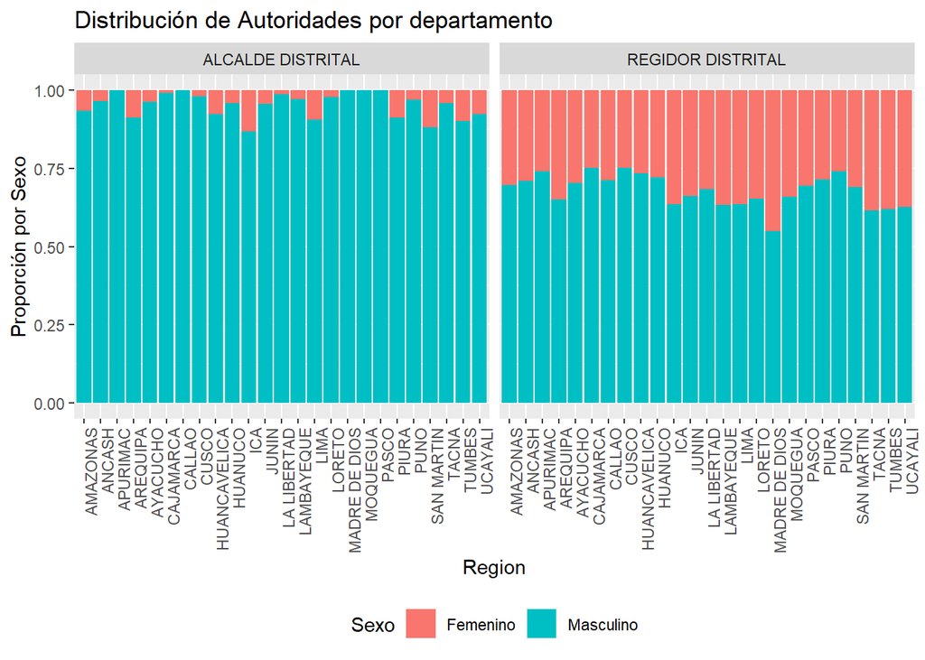

```r
autoridades %>%
  group_by(Región, Sexo, `Cargo electo`, Distrito) %>%
  summarize(count = n()) %>%
  ggplot(aes(x = Región, y = count, fill = Sexo)) +
  geom_bar(stat = "identity", position = "fill") +
  facet_wrap(~ `Cargo electo` ) +
  theme(legend.position = "bottom") +
  xlab("Region") +
  ylab("Proporción por Sexo") +
  ggtitle("Distribución de Autoridades por departamento")+
  theme(axis.text.x = element_text(angle = 90, hjust = 1))
```

```r
#ggsave("grafico3.png", plot = last_plot(), width = 6, height = 4, units = "in")
```

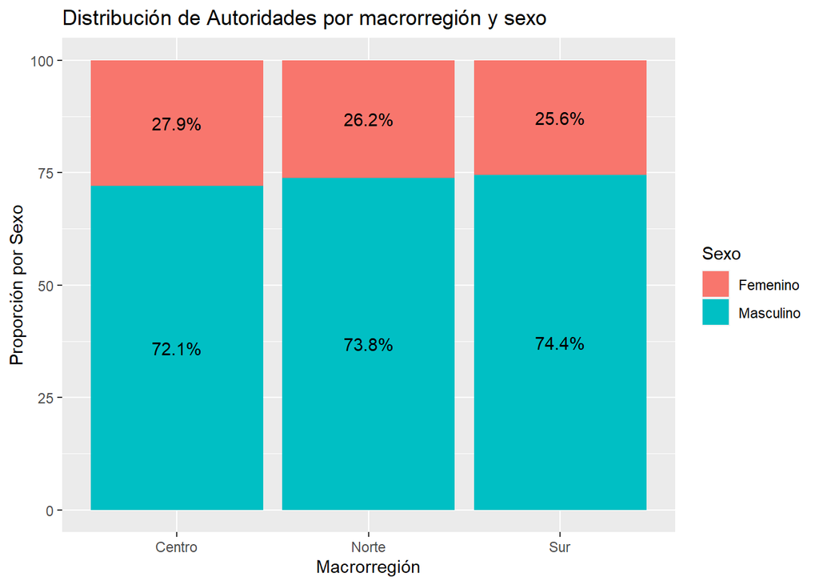

```r
#Distribución de autoridades por Macrorregión (Norte, Centro y Sur)
autoridades <- as.data.frame(autoridades)

autoridades_2 <- autoridades |>
  mutate(Joven = ifelse(is.na(Joven), "No Joven", Joven)) |>
  mutate(Nativo = ifelse(is.na(Nativo), "No Nativo", Nativo)) |>
  mutate(macrorregion = if_else(Región %in% c("AMAZONAS" , "CAJAMARCA","LA LIBERTAD", "LAMBAYEQUE", "LORETO", "PIURA", "SAN MARTIN", "TUMBES"), "Norte",
                                if_else(Región %in% c("LIMA","ANCASH", "CALLAO", "HUANCAVELICA", "HUANUCO", "JUNIN","MADRE DE DIOS", "PASCO", "UCAYALI"), "Centro",
                                        if_else(Región %in% c("AREQUIPA","APURIMAC", "AYACUCHO", "CUSCO","ICA","MOQUEGUA", "PUNO", "TACNA"), "Sur", "NA"))))


autoridades_2 %>%
  group_by(macrorregion, Sexo) %>%
  summarize(count = n()) %>%
  mutate(percent = count / sum(count) * 100) %>%
  ggplot(aes(x = macrorregion, y = percent, fill = Sexo)) +
  geom_bar(stat = "identity", position = "stack") +
  geom_text(aes(label = paste0(round(percent, 1), "%")), position = position_stack(vjust = 0.5)) +
  ggtitle("Distribución de Autoridades por macrorregión y sexo") +
  xlab("Macrorregión") +
  ylab("Proporción por Sexo")
```

```r
#ggsave("grafico4.png", plot = last_plot(), width = 6, height = 4, units = "in")
```

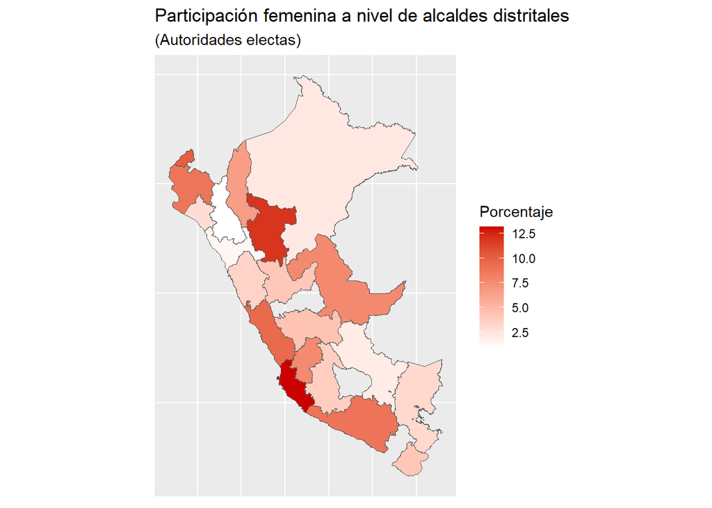

```r
# se importa el df de para graficar el mapa por autoridades electas
df_mapa_autoridades <- map_DEP

df_mapa_autoridades<-left_join(df_mapa_autoridades, autoridades_map, by=c("DEPARTAMENTO"="Región"))

# se grafica la participacion femenina de las alcadesas electas
df_mapa_autoridades |>
  filter(Sexo=="Femenino", `Cargo electo`  == "ALCALDE DISTRITAL") |>
  ggplot() +
  aes(geometry=geometry)+
  geom_sf(aes(fill=percent)) +
  scale_fill_gradient (low="white", high="red3", name = "Porcentaje")+
  labs(title = "Participación femenina a nivel de alcaldes distritales",
       subtitle="(Autoridades electas)") +
  theme(axis.line = element_blank(),
        axis.text.x = element_blank(),
        axis.text.y = element_blank(),
        axis.ticks = element_blank(),
        axis.title.x = element_blank(),
        axis.title.y = element_blank())
```

A partir de este grafico, se observa que si bien Ica y San Martín no eran las regiones con mayor participación femenina en las elecciones a nivel de alcaldes distritales, sí son aquellas en las que mayor postulantes femeninas fueron electas. Por otro lado, se resalta que los departamentos en los que casi ninguna candidata femenina fue electa son Apurímac, Moquegua y Pasco.

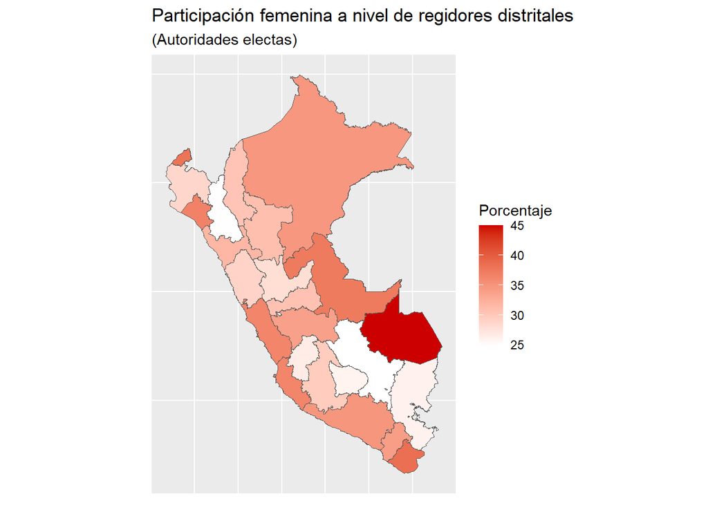

```r
# se grafica la participacion femenina de las regidoras electas
df_mapa_autoridades |>
  filter(Sexo=="Femenino", `Cargo electo` =="REGIDOR DISTRITAL") |>
  ggplot() +
  aes(geometry=geometry)+
  geom_sf(aes(fill=percent)) +
  scale_fill_gradient (low="white", high="red3", name = "Porcentaje")+
  labs(title = "Participación femenina a nivel de regidores distritales",
       subtitle="(Autoridades electas)") +
  theme(axis.line = element_blank(),
        axis.text.x = element_blank(),
        axis.text.y = element_blank(),
        axis.ticks = element_blank(),
        axis.title.x = element_blank(),
        axis.title.y = element_blank())
```

A partir de este grafico, se observa que, si bien el departamento de Madre de Dios no era uno de los que contaba con mayor participación femenina a nivel de regidores distritales, sí lo son respecto a la cantidad de mujeres electas con dicho cargo. Por otro lado, Cajamarca y Cusco son las regiones en que menos mujeres fueren electas como regidores distritales.

## Conclusiones

- Si bien, desde el año 1955, las mujeres en el Perú adquirieron el derecho a votar y a ser elegidas, la participación política de la mujer se ha caracterizado por ser minoritaria al momento de postular como al momento de ser elegida. Esto es reflejado aun en las elecciones municipales del 2018.
- Para las candidaturas,
  - Existe una mayor cantidad de hombres que postulan a cargos de regidores como alcaldes; sin embargo, las mujeres estan mas presentes en las candidaturas a regidores.
  - Si desagregamos estos datos a nivel departamental, no existe mucha diferencia entre quienes postulan por departamentos para los puestos de regidores distritales, pero si para los puestos de alcalde distrital.
- Para las autoridades electas,
  - Existe variabilidad en la presencia de mujeres electas como representantes que se va reduciendo mientras agregamos los datos niveles geograficos. Existe una mayor representacion masculina para los puestos de regidores como de alcaldia. Sin embargo, parece que las mujeres ocupan mas puestos en el caso de regidores distritales
  - En el caso de las elecciones a regidores, se revierte la situacion de mayoria masculina si nos centramos en autoridades jovenes. En el caso de las elecciones de alcaldia, las mujeres representan una minoria tanto para autoridades jovenes como no jovenes.
- Como recomendaciones, Reconocemos que hacen falta políticas de sensibilización y de educación para mejorar el escenario en las elecciones de alcaldesas Mejoras en la ley de cuotas sobre los partidos para mejorar la presencia femenina de regidoras y alcaldesas a nivel nacional.

## Bibliografía

Dirección Nacional de educación y formación cívica ciudadana. (2022). *Paridad y alternancia en las elecciones internas* ERM 2022. Direccion Nacional de Educación y Formación Cívico Ciudadana. (2020). *Paridad y alternancia de género en las listas electorales Ley 31030.* Gerring, J. (2012). *Mere description.* British Journal of Political Science, 42(4), 721–746. [https://doi.org/10.1017/S0007123412000130] Infogob (2023). *Observatorio para la gobernabilidad.* Disponible en: [https://infogob.jne.gob.pe/]